# Agent based simulation of a Perpetual Futures Market

### Analysing the accuracy of the peg

To analyse the properties of the ‘peg’, we use Shewhart Charts (Figure 3) - a line graph representing a measure over time, with bounds representing an upper and lower control limit typically set at $\pm3$ standard deviations from the mean, referred to here as the ‘Center’. In the case of Perpetual Future Premiums, this approximates the Spot Price at time $t$, as the $Premium_t$ is the deviation of the Perp price from the spot price at time $t$. The points marked in red are premiums that are more than 3 standard deviations away from the mean, referred to as ‘Violations’. The points in orange represent ‘Runs’ consecutive sequences of premiums that move away from the Center - an indication of the process deviating from the norm. These three estimates will be our primary tools to explore the quality of the peg across a diverse range of parameters in the simulations below.

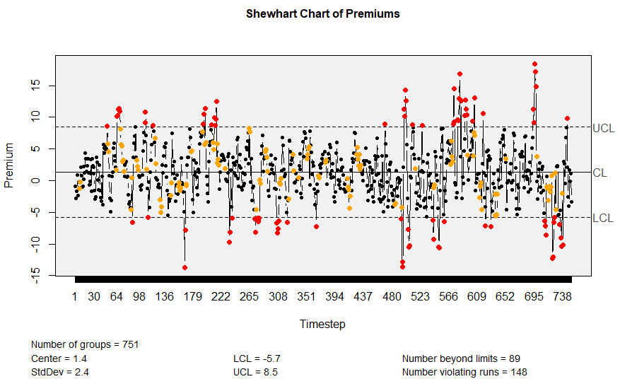

**Figure 3: The control chart for a simulation run with $\mu = 1, \sigma = 0.5, S_0 = 100, \sigma_c = 10, \sigma_n = 10$. The upper and lower control limits are $8.5$ and $-5.7$ respectively, with the center of the distribution at $1.4$, slightly above the expected $0$. The number of ‘violations’ - Premiums greater than 3 standard deviations from the center - are $89$, marked in Red. Finally, the number violating runs is $148$ - this is a count of the number of consecutive premiums that are continuously increasing or decreasing away from the center - an indication of the process deviating from the norm (in Orange).**

### Simulation Parameters

The behavior of the traders is entirely determined by the two price signals from the Perp market itself, the Spot market, and the following parameters:

#### Forecasting Parameters:

$\sigma_f$: The weightage given by a trader to fundamentalist strategies. This is set to $0$ as discussed in the methods section above.

$\sigma_c$: The weightage given by a trader to chartist strategies

$\sigma_n$: The weightage given by a trader to noise strategies

$\sigma_\epsilon$: A volatility parameter used by the noise strategy to produce forecasts

$l_{min}, l_{max}$: The time horizon used by the Chartist strategy to generate forecasts

#### Trading parameters:

$k_{max}$: The range above and below the forecast price from which the trader selects their Bid and Ask prices

$bias$: Modulates the tendency for a trader to prefer positional or basis trading startegies based on whether they are trading long or short.

$exit_{probability}$: The probability of exiting the market at each timestep

$\tau$: all Bids and Asks more than $\tau$ before the latest Bid or Ask are expired

$cohort_{size}$: The number of randomly drawn traders who participate in trading at each timestep